# **What is Matplotlib?**

- Matplotlib is one of the best Python visualization library for generating powerful yet simple visualization.
- Matplotlib is a low level graph plotting library in python that serves as a visualization utility. Matplotlib was created by John D. Hunter. Matplotlib is open source and we can use it freely.
- Matplotlib is mostly written in python, a few segments are written in C, Objective-C and Javascript for Platform compatibility.

# **Key Features of Matplotlib:**

- **Versatility**: Matplotlib can generate a wide range of plots, including line plots, scatter plots, bar plots, histograms, pie charts, and more.
- **Customization**: It offers extensive customization options to control every aspect of the plot, such as line styles, colors, markers, labels, and annotations.
- **Integration with NumPy**: Matplotlib integrates seamlessly with NumPy, making it easy to plot data arrays directly.
- **Publication Quality**: Matplotlib produces high-quality plots suitable for publication with fine-grained control over the plot aesthetics.
- **Extensible**: Matplotlib is highly extensible, with a large ecosystem of add-on toolkits and extensions like Seaborn, Pandas plotting functions, and Basemap for geographical plotting.
- **Cross-Platform**: It is platform-independent and can run on various operating systems, including Windows, macOS, and Linux.
- **Interactive Plots**: Matplotlib supports interactive plotting through the use of widgets and event handling, enabling users to explore data dynamically.

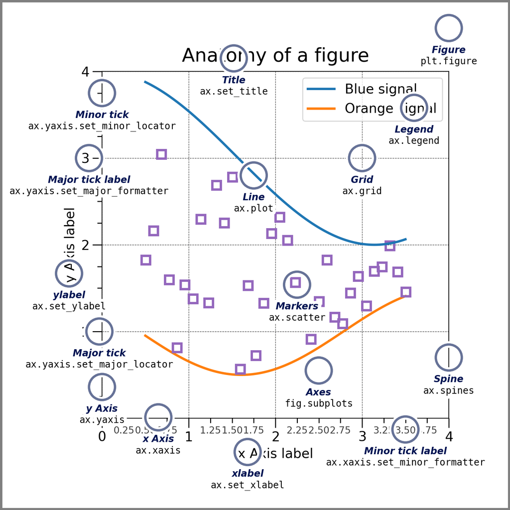

[output not shown]

# **Basic Components or Parts of Matplotlib Figure**

The parts of a Matplotlib figure include (as shown in the figure above):

- **Figures in Matplotlib:** The Figure object is the top-level container for all elements of the plot. It serves as the canvas on which the plot is drawn. You can think of it as the blank sheet of paper on which you’ll create your visualization.
- **Axes in Matplotlib:** Axes are the rectangular areas within the figure where data is plotted. Each figure can contain one or more axes, arranged in rows and columns if necessary. Axes provide the coordinate system and are where most of the plotting occurs.
- **Axis in Matplotlib:** Axis objects represent the x-axis and y-axis of the plot. They define the data limits, tick locations, tick labels, and axis labels. Each axis has a scale and a locator that determine how the tick marks are spaced.
- **Marker in Matplotlib:** Markers are symbols used to denote individual data points on a plot. They can be shapes such as circles, squares, triangles, or custom symbols. Markers are often used in scatter plots to visually distinguish between different data points.
- **Adding lines to Figures:** Lines connect data points on a plot and are commonly used in line plots, scatter plots with connected points, and other types of plots. They represent the relationship or trend between data points and can be styled with different colors, widths, and styles to convey additional information.
- **Matplotlib Title:** The title is a text element that provides a descriptive title for the plot. It typically appears at the top of the figure and provides context or information about the data being visualized.
- **Axis Labels in Matplotlib:** Labels are text elements that provide descriptions for the x-axis and y-axis. They help identify the data being plotted and provide units or other relevant information.
- **Ticks:** Tick marks are small marks along the axis that indicate specific data points or intervals. They help users interpret the scale of the plot and locate specific data values.
- **Tick Labels:** Tick labels are text elements that provide labels for the tick marks. They usually display the data values corresponding to each tick mark and can be customized to show specific formatting or units.
- **Matplotlib Legend:** Legends provide a key to the symbols or colors used in the plot to represent different data series or categories. They help users interpret the plot and understand the meaning of each element.
- **Matplotlib Grid Lines:** Grid lines are horizontal and vertical lines that extend across the plot, corresponding to specific data intervals or divisions. They provide a visual guide to the data and help users identify patterns or trends.
- **Spines of Matplotlib Figures:** Spines are the lines that form the borders of the plot area. They separate the plot from the surrounding whitespace and can be customized to change the appearance of the plot borders.

# **Hands-on Matplotlib Module**

## Install Required Libraries

```python
# Install matplotlib
!pip install matplotlib
```

## How to Import modules?

```python
# Importing necessary libraries/modules
import matplotlib.pyplot as plt
import numpy as np
import pandas as pd
import math
```

## Check Version of Modules

```python
import matplotlib
# check version
print(matplotlib.__version__)
```

```
3.7.1
```

## How to Import and Create Data?

### Create Data Using Numpy

```python
# Fetching/Creating Datas

x = np.arange(1, 11)
y = 2 * x + 5
z = x ** 2

# Create dataFrame

df = pd.DataFrame({'x': x, 'y': y, 'z': z})
df.head()
```

|  | x | y | z |
| --- | --- | --- | --- |
| 0 | 1 | 7 | 1 |
| 1 | 2 | 9 | 4 |
| 2 | 3 | 11 | 9 |
| 3 | 4 | 13 | 16 |
| 4 | 5 | 15 | 25 |

### Import/Fetch Data from CSV File

```python
p_df = pd.read_csv('https://raw.githubusercontent.com/jsdhami/Python-For-Research/main/Data/p_table.csv')
p_df.head()

# w_df = pd.read_csv('https://raw.githubusercontent.com/jsdhami/Python-For-Research/main/Data/w_table.csv')
# w_df.head()
```

|  | AtomicNumber | Symbol | Name | AtomicMass | CPKHexColor | ElectronConfiguration | Electronegativity | AtomicRadius | IonizationEnergy | ElectronAffinity | OxidationStates | StandardState | MeltingPoint | BoilingPoint | Density | GroupBlock | YearDiscovered |
| --- | --- | --- | --- | --- | --- | --- | --- | --- | --- | --- | --- | --- | --- | --- | --- | --- | --- |
| 0 | 1 | H | Hydrogen | 1.008000 | FFFFFF | 1s1 | 2.20 | 120.0 | 13.598 | 0.754 | +1, -1 | Gas | 13.81 | 20.28 | 0.000090 | Nonmetal | 1766 |
| 1 | 2 | He | Helium | 4.002600 | D9FFFF | 1s2 | NaN | 140.0 | 24.587 | NaN | 0 | Gas | 0.95 | 4.22 | 0.000179 | Noble gas | 1868 |
| 2 | 3 | Li | Lithium | 7.000000 | CC80FF | [He]2s1 | 0.98 | 182.0 | 5.392 | 0.618 | +1 | Solid | 453.65 | 1615.00 | 0.534000 | Alkali metal | 1817 |
| 3 | 4 | Be | Beryllium | 9.012183 | C2FF00 | [He]2s2 | 1.57 | 153.0 | 9.323 | NaN | +2 | Solid | 1560.00 | 2744.00 | 1.850000 | Alkaline earth metal | 1798 |
| 4 | 5 | B | Boron | 10.810000 | FFB5B5 | [He]2s2 2p1 | 2.04 | 192.0 | 8.298 | 0.277 | +3 | Solid | 2348.00 | 4273.00 | 2.370000 | Metalloid | 1808 |

### **Select Required data from table**

```python
# How to select Data From table
x = p_df['AtomicNumber']
y = p_df['AtomicMass']
z = p_df['AtomicRadius']

# index dataFrame
df = pd.DataFrame({'x': x, 'y': y, 'z': z})
df.head()
```

|  | x | y | z |
| --- | --- | --- | --- |
| 0 | 1 | 1.008000 | 120.0 |
| 1 | 2 | 4.002600 | 140.0 |
| 2 | 3 | 7.000000 | 182.0 |
| 3 | 4 | 9.012183 | 153.0 |
| 4 | 5 | 10.810000 | 192.0 |

## How to Plot the Graph?

### Old version Way of Matplotlib

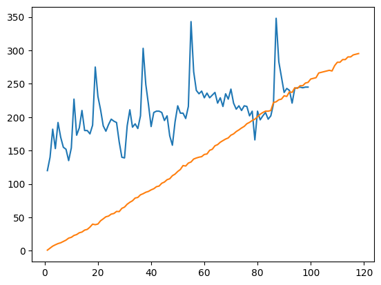

```python
# Plot
plt.plot(x, z)
plt.plot(x, y)
plt.show()
# it's old way to plot
```

### New Version Way of Matplotlib

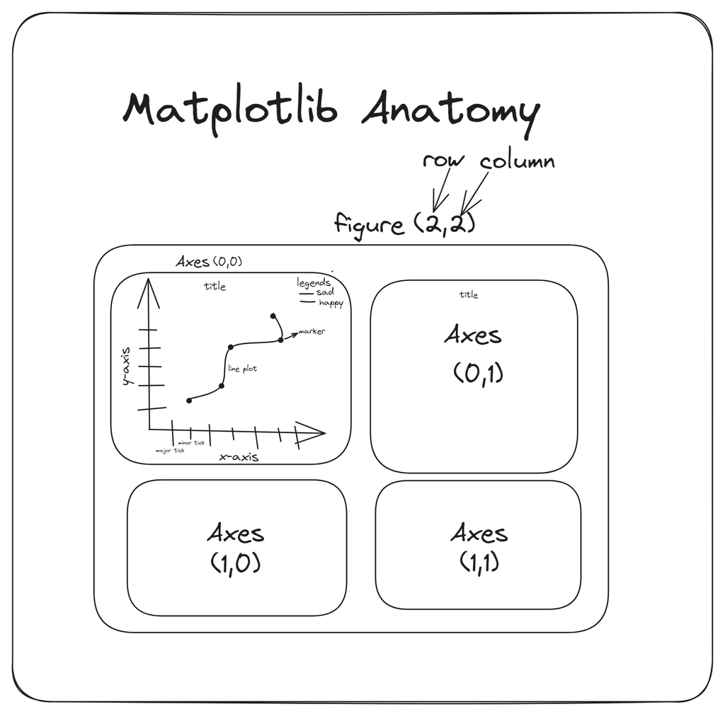

### line plot

```
      Angle         Value
0 -6.283185  2.449294e-16
1 -5.783185  4.794255e-01
2 -5.283185  8.414710e-01
3 -4.783185  9.974950e-01
4 -4.283185  9.092974e-01
```

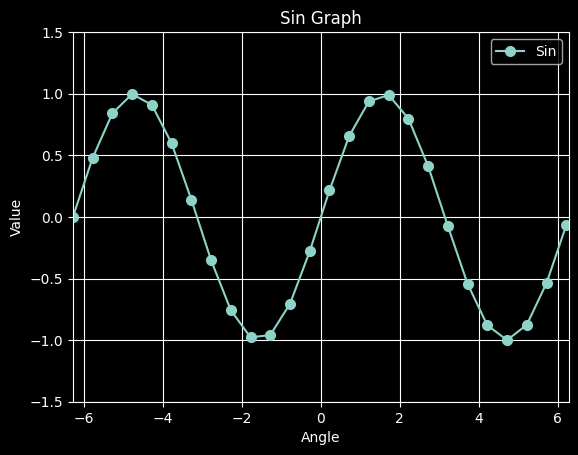

```python
# start, end, step/diff.
x = np.arange(-2*math.pi, 2*math.pi, 0.5)

y = np.sin(x)

#use style
plt.style.use('dark_background')

# Create dataFrame and indexing
sinDF = pd.DataFrame({'Angle': x, 'Value': y})

# print top datas
print(sinDF.head())

# Plot

# create figure and axes
fig, ax = plt.subplots()

# plot graph
ax.plot(x, y, 'o-', markeredgewidth=2)

# labeling
ax.set_title('Sin Graph')

ax.set_xlabel('Angle')
ax.set_ylabel('Value')

# fix limit on axis
ax.set_ylim(-1.5, 1.5)
ax.set_xlim(-2*math.pi, 2*math.pi)

# ticks label
# ax.set_xticks([-2*math.pi, -math.pi, 0, math.pi, 2*math.pi])
# ax.set_yticks([-1.5, -1, 0, 1, 1.5])



# grid
ax.grid(True)

# legend
plt.legend(['Sin'])

# show graph
plt.show()
```

### scatter plot

```python
# read data
weather_dF= pd.read_csv('https://raw.githubusercontent.com/jsdhami/Python-For-Research/main/Data/seattle-weather.csv')

weather_dF.head()
```

|  | date | precipitation | temp_max | temp_min | wind | weather |
| --- | --- | --- | --- | --- | --- | --- |
| 0 | 2012-01-01 | 0.0 | 12.8 | 5.0 | 4.7 | drizzle |
| 1 | 2012-01-02 | 10.9 | 10.6 | 2.8 | 4.5 | rain |
| 2 | 2012-01-03 | 0.8 | 11.7 | 7.2 | 2.3 | rain |
| 3 | 2012-01-04 | 20.3 | 12.2 | 5.6 | 4.7 | rain |
| 4 | 2012-01-05 | 1.3 | 8.9 | 2.8 | 6.1 | rain |

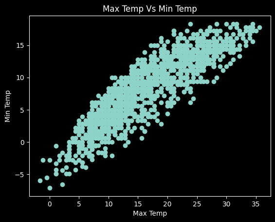

```python
max_temp = weather_dF['temp_max']
min_temp = weather_dF['temp_min']


# style
plt.style.use('dark_background')

# create figure and axes
fig, ax = plt.subplots()

# scatter plot
ax.scatter(max_temp, min_temp)

# labeling
ax.set_title('Max Temp Vs Min Temp')
ax.set_xlabel('Max Temp')
ax.set_ylabel('Min Temp')

# show graph
plt.show()
```

### Bar Plot

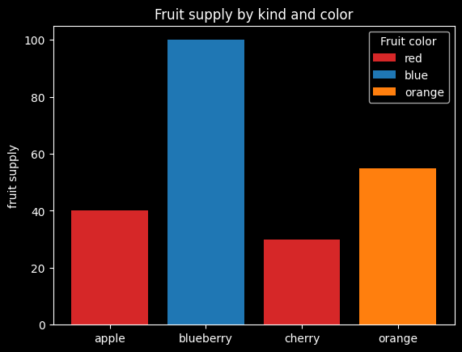

```python
# Simply bar diagram

fig, ax = plt.subplots()

fruits = ['apple', 'blueberry', 'cherry', 'orange']

counts = [40, 100, 30, 55]

bar_labels = ['red', 'blue', '_red', 'orange']

bar_colors = ['tab:red', 'tab:blue', 'tab:red', 'tab:orange']

ax.bar(fruits, counts, label=bar_labels, color=bar_colors)

ax.set_ylabel('fruit supply')
ax.set_title('Fruit supply by kind and color')
ax.legend(title='Fruit color')

plt.show()
```

### Steam Plot

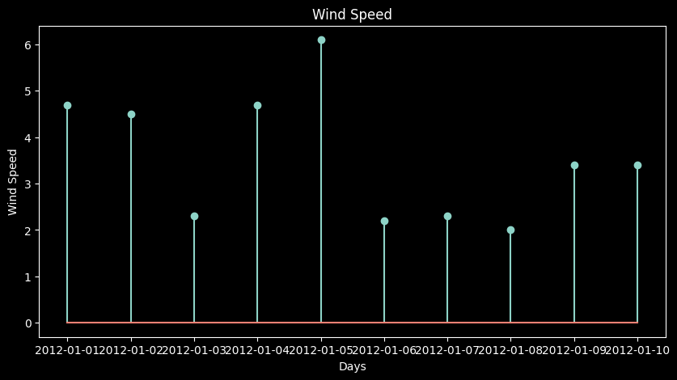

```python
weather_F = weather_dF.head(10)

wind = weather_F['wind']
date = weather_F['date']

# plot
fig, ax = plt.subplots()

fig.set_size_inches(10, 5)

ax.stem(date, wind)

# labeling
ax.set_title('Wind Speed')
ax.set_xlabel('Days')
ax.set_ylabel('Wind Speed')

plt.show()
```

### Fill Between Plot

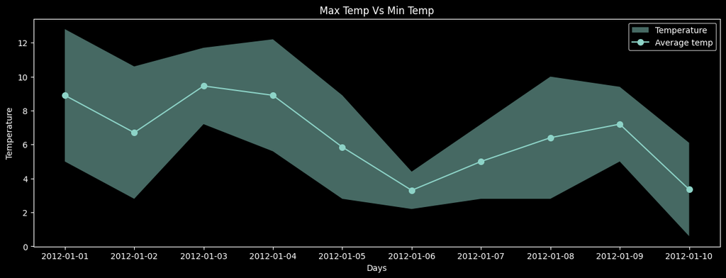

```python
# data
weather = weather_dF.head(10)

min_temp = weather['temp_min']
max_temp = weather['temp_max']
date = weather['date']

avg_temp =(min_temp + max_temp) / 2

# style
plt.style.use('dark_background')

# plot
fig, ax = plt.subplots()

# fix the size of fig
fig.set_size_inches(15, 5)

# plot
ax.fill_between(date, min_temp, max_temp, alpha=.5, linewidth=0)

# line plot with scatter
ax.plot(date, avg_temp, 'o-', markeredgewidth=2)


# labeling
ax.set_title('Max Temp Vs Min Temp')
ax.set_xlabel('Days')
ax.set_ylabel('Temperature')

# add legend
plt.legend(['Temperature', 'Average temp'])

# show graph
plt.show()
```

### Stack plot

[figure not shown]

```python
w_df = weather_dF.head(10)
date = w_df['date']
temp_max = w_df['temp_max']
temp_min = w_df['temp_min']
temp_avg = (temp_max + temp_min) / 2

# style
plt.style.use('dark_background')

# plot
fig, ax = plt.subplots()
fig.set_size_inches(15, 5)

ax.stackplot(date, temp_max, temp_min, temp_avg)

# labeling
ax.set_title('Max Temp Vs Min Temp VS Avg')
ax.set_xlabel('Days')
ax.set_ylabel('Temperature')

# add legend
plt.legend(['Min Temp', 'Avg Temp', 'Max Temp'])

# show graph
plt.show()
```

### Stairs plot

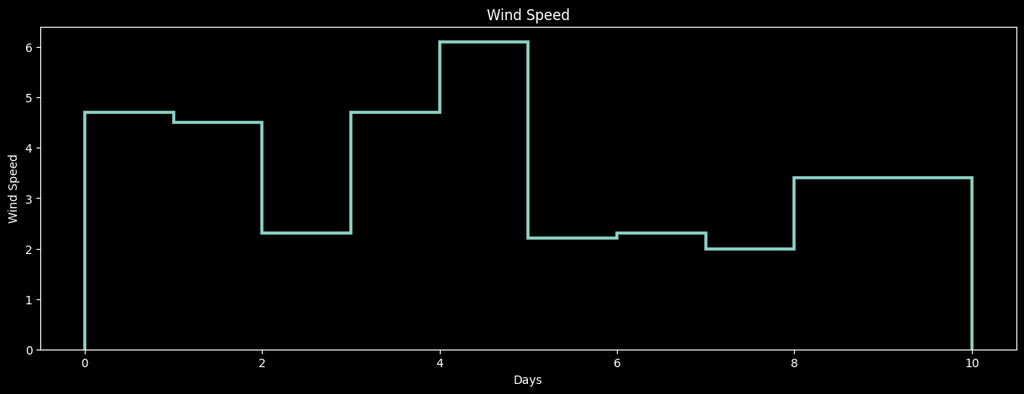

```python
# data
wData = weather_dF.head(10)

wind = wData['wind']

# style
plt.style.use('dark_background')

# plot
fig, ax = plt.subplots()
fig.set_size_inches(15, 5)

ax.stairs(wind, linewidth=2.6)

# labeling
ax.set_title('Wind Speed')
ax.set_xlabel('Days')
ax.set_ylabel('Wind Speed')

# show graph
plt.show()
```

# Multiple Axes inside Figure

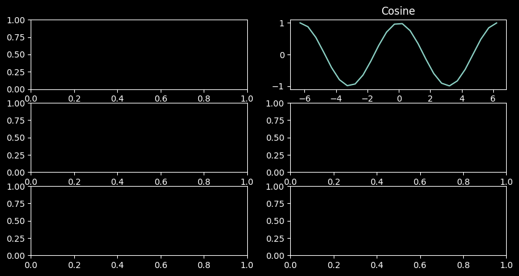

```python
x = np.arange(-2*math.pi, 2*math.pi, 0.5)
y = np.sin(x)
z = np.cos(x)

# style
plt.style.use('dark_background')
fig, ax = plt.subplots(3, 2)

fig.set_size_inches(10, 5)

# ax[0, 0].plot(x, y)

ax[0, 1].plot(x, z)

ax[0, 1].set_title('Cosine')



plt.show()
```

[figure not shown]

```python
# use style
plt.style.use('dark_background')
# Check for more style https://matplotlib.org/stable/gallery/style_sheets/style_sheets_reference.html

# plot with fig and ax
fig, ax = plt.subplots(1, 2,
     figsize=(10, 5)
    # facecolor='black'
    # edgecolor='white'
    # linewidth=10
    # linestyle='--'
)
ax[0].plot(x, y)
ax[1].plot(x, z)
ax[0].set_title('Atomic Mass Vs Atomic Number')
ax[1].set_title('Atomic Radius Vs Atomic Number ')
ax[0].set_xlabel('Atomic Number')
ax[1].set_xlabel('Atomic Number')
ax[0].set_ylabel('Atomic Mass')
ax[1].set_ylabel('Atomic Radius')

ax[0].grid(True)

ax[1].grid(True)

plt.show()

# save fig
# plt.savefig('plot.png')
```

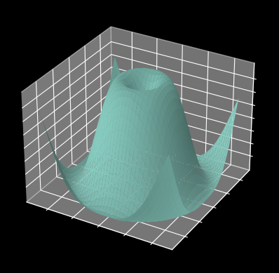

```python
plt.style.use('dark_background')

# Make data
X = np.arange(-5, 5, 0.25)
Y = np.arange(-5, 5, 0.25)
X, Y = np.meshgrid(X, Y)
R = np.sqrt(X**2 + Y**2)
Z = np.sin(R)

# Plot the surface
fig, ax = plt.subplots(subplot_kw={"projection": "3d"})
ax.plot_surface(X, Y, Z)

ax.set(xticklabels=[],
       yticklabels=[],
       zticklabels=[])

plt.show()
```

# **3D Plots**

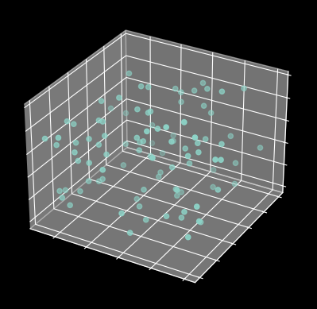

```python
# Make data
np.random.seed(19680801)
n = 100
rng = np.random.default_rng()
xs = rng.uniform(23, 32, n)
ys = rng.uniform(0, 100, n)
zs = rng.uniform(-50, -25, n)

# Plot
fig, ax = plt.subplots(subplot_kw={"projection": "3d"})
ax.scatter(xs, ys, zs)

ax.set(xticklabels=[],
       yticklabels=[],
       zticklabels=[])

plt.show()
```

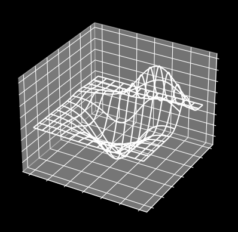

```python
from mpl_toolkits.mplot3d import axes3d
# Make data
X, Y, Z = axes3d.get_test_data(0.05)

# Plot
fig, ax = plt.subplots(subplot_kw={"projection": "3d"})
ax.plot_wireframe(X, Y, Z, rstride=10, cstride=10)

ax.set(xticklabels=[],
       yticklabels=[],
       zticklabels=[])

plt.show()
```

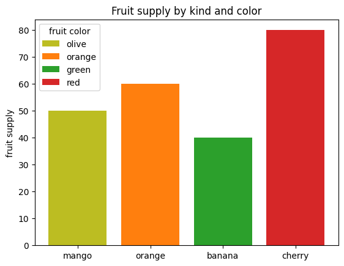

```python
import matplotlib.pyplot as plt
fig, ax=plt.subplots()
fruits= ['mango', 'orange', 'banana', 'cherry']
counts= [50,60,40,80]
bar_labels= ['olive', 'orange', 'green', 'red']
bar_colors= ['tab:olive', 'tab:orange', 'tab:green', 'tab:red']

ax.bar(fruits, counts, label=bar_labels, color=bar_colors)

ax.set_ylabel('fruit supply')
ax.set_title('Fruit supply by kind and color')
ax.legend(title='fruit color')
plt.show()
```